# Bouy Data Dive

Chelsey Wegener

9/30/2020

Notes:  
-Accessed and downloaded all data on September 30, 2020

-I downloaded all data available from 1/1/2017-12/31/2019. None of the following data sources had air temperature so I’ll look into additional data sources for that.

-I didn’t graph these on the same y-axis scale so we can see all the data points during this initial data investigation.

-China camp http://cdmo.baruch.sc.edu/aqs/zips.cfm Data logged every 15minutes. Requested citation format: NOAA National Estuarine Research Reserve System (NERRS). System-wide Monitoring Program. Data accessed from the NOAA NERRS Centralized Data Management Office website: http://cdmo.baruch.sc.edu/; accessed 30 September 2020.

-Richardson Bay/NERR data. Data logged every 15minutes. pH, salinity, and disolved oxygen available. No air temperature

-EOS https://oceanview.pfeg.noaa.gov/erddap/tabledap/rtcctdRTCysi.html. Data logged every 6 hours. time in UTC. Some salinity data points that need to be removed. Should I use this link? http://erddap.cencoos.org/erddap/tabledap/tiburon-water-tibc1.html. ph and salinity available. No air temperature.

-Point Fort http://erddap.cencoos.org/erddap/tabledap/fort-point.html?time%2Csea_water_temperature%2Csea_water_temperature_qc_agg%2Cz&time%3E%3D2020-09-20T21%3A07%3A41Z&time%3C%3D2020-09-29T12%3A00%3A00Z. time in UTC. Data logged every 6 hours. Salinity available, no dissolved oxygen or pH. Only able to use salinity. I’ll look into additional data sources.

Notes for self:  
download data at instrument frequency–> plot –> filter outliers (same for all sites) –> median to same frequency –>analysis

Interested in salinity, air temperature during low tides, season, pH or DO and its affect on density.

Read papers in bookmark folder

Data cleaning: potentially get rid of values that are 3 standard deviations from the mean.

Look for depth of instrament.

Might need to filter by tidal height.

Richardson Bay

```r
rb17<-read.csv("C:/Users/chels/Box Sync/Thesis/Data/Working data/Bouy data/rich_bay_2017_2018_r.csv", header = TRUE, sep=",", fileEncoding="UTF-8-BOM", stringsAsFactors = FALSE)

rb18<-read.csv("C:/Users/chels/Box Sync/Thesis/Data/Working data/Bouy data/rich_bay_2018_2019_r.csv", header = TRUE, sep=",", fileEncoding="UTF-8-BOM", stringsAsFactors = FALSE)

rb19<-read.csv("C:/Users/chels/Box Sync/Thesis/Data/Working data/Bouy data/rich_bay_2019_2020_r.csv", header = TRUE, sep=",", fileEncoding="UTF-8-BOM", stringsAsFactors = FALSE)
```

Combine

```r
rb<-rbind(rb17,rb18,rb19)
```

Convert the columns

```r
rb$Date<-as.POSIXct(rb$DateTimeStamp, format = c("%m/%d/%y %H:%M"))
```

Graph

```r
rbsal<-ggplot(data = rb, mapping = aes(x = Date, y = Sal, color=Sal)) + geom_point()  +stat_smooth(colour="green")+ggtitle("")+ theme(plot.title = element_text(size = 12, face = "plain")) +theme(axis.text=element_text(size=12),axis.title=element_text(size=12,face="plain")) + ylab("Salinity") + xlab("") + theme(panel.grid.major = element_blank(), panel.grid.minor = element_blank(), panel.background = element_blank(), axis.line = element_line(colour = "black"))

rbph<-ggplot(data = rb, mapping = aes(x = Date, y = pH, color=pH)) + geom_point()  +stat_smooth(colour="green")+ggtitle("")+  theme(plot.title = element_text(size = 12, face = "plain")) +theme(axis.text=element_text(size=12),axis.title=element_text(size=12,face="plain")) + ylab("pH") + xlab("") + theme(panel.grid.major = element_blank(), panel.grid.minor = element_blank(), panel.background = element_blank(), axis.line = element_line(colour = "black"))

rbdo<-ggplot(data = rb, mapping = aes(x = Date, y = DO_mgl, color=DO_mgl)) + geom_point()  +stat_smooth(colour="green")+ggtitle("")+ theme(plot.title = element_text(size = 12, face = "plain")) +theme(axis.text=element_text(size=12),axis.title=element_text(size=12,face="plain")) + ylab("Dissolved Oxygen (mg/l)") + xlab("") + theme(panel.grid.major = element_blank(), panel.grid.minor = element_blank(), panel.background = element_blank(), axis.line = element_line(colour = "black"))

rbwtemp<-ggplot(data = rb, mapping = aes(x = Date, y = Temp, color=Temp)) + geom_point()  +stat_smooth(colour="green")+ggtitle("")+ theme(plot.title = element_text(size = 12, face = "plain")) +theme(axis.text=element_text(size=12),axis.title=element_text(size=12,face="plain")) + ylab("Water temperature (C)") + xlab("") + theme(panel.grid.major = element_blank(), panel.grid.minor = element_blank(), panel.background = element_blank(), axis.line = element_line(colour = "black"))

rbstack<-ggarrange(rbsal, rbph, rbdo, rbwtemp, ncol= 4, nrow = 1)
rbgraph<-annotate_figure(rbstack,
                top = text_grob("Richardson Bay", color = "black", face = "plain", size = 14), left = text_grob("", color = "black", rot = 90, size=12))
```

EOS bouy data

```r
eos<-read.csv("C:/Users/chels/Box Sync/Thesis/Data/Working data/Bouy data/eos_bouy_r.csv", header = TRUE, sep=",", fileEncoding="UTF-8-BOM", stringsAsFactors = FALSE)
```

Convert columns

```r
eos$date<-as.Date(eos$date, format = "%m/%d/%Y")
```

Graph

```r
eossal<-ggplot(data = eos, mapping = aes(x = date, y = salinity, color=salinity)) + geom_point()  +stat_smooth(colour="green")+ggtitle("") + theme(plot.title = element_text(size = 12, face = "plain")) +theme(axis.text=element_text(size=12),axis.title=element_text(size=12,face="plain")) + ylab("Salinity") + xlab("") + theme(panel.grid.major = element_blank(), panel.grid.minor = element_blank(), panel.background = element_blank(), axis.line = element_line(colour = "black"))

eosph<-ggplot(data = eos, mapping = aes(x = date, y = ph, color=ph)) + geom_point()  +stat_smooth(colour="green")+ggtitle("") + theme(plot.title = element_text(size = 12, face = "plain")) +theme(axis.text=element_text(size=12),axis.title=element_text(size=12,face="plain")) + ylab("pH") + xlab("") + theme(panel.grid.major = element_blank(), panel.grid.minor = element_blank(), panel.background = element_blank(), axis.line = element_line(colour = "black"))

eoswtemp<-ggplot(data = eos, mapping = aes(x = date, y = temperature, color=temperature)) + geom_point()  +stat_smooth(colour="green")+ggtitle("") + theme(plot.title = element_text(size = 12, face = "plain")) +theme(axis.text=element_text(size=12),axis.title=element_text(size=12,face="plain")) + ylab("Water temperature (C)") + xlab("") + theme(panel.grid.major = element_blank(), panel.grid.minor = element_blank(), panel.background = element_blank(), axis.line = element_line(colour = "black"))

eosstack<-ggarrange(eossal, eosph, eoswtemp, ncol= 3, nrow = 1)
eosgraph<-annotate_figure(eosstack,
                top = text_grob("Tiburon", color = "black", face = "plain", size = 14), left = text_grob("", color = "black", rot = 90, size=12))
```

Fort point data

```r
fp<-read.csv("C:/Users/chels/Box Sync/Thesis/Data/Working data/Bouy data/fort_point_r.csv", header = TRUE, sep=",", fileEncoding="UTF-8-BOM", stringsAsFactors = FALSE)
```

Convert columns

```r
fp$date<-as.Date(fp$date, format = "%Y-%m-%d")
```

Graph

```r
fpsal<-ggplot(data = fp, mapping = aes(x = date, y = sea_water_practical_salinity, color=sea_water_practical_salinity)) + geom_point()  +stat_smooth(colour="green")+ggtitle("") + theme(plot.title = element_text(size = 12, face = "plain")) +theme(axis.text=element_text(size=12),axis.title=element_text(size=12,face="plain")) + ylab("Salinity") + xlab("") + theme(panel.grid.major = element_blank(), panel.grid.minor = element_blank(), panel.background = element_blank(), axis.line = element_line(colour = "black"))

fpwtemp<-ggplot(data = fp, mapping = aes(x = date, y = sea_water_temperature, color=sea_water_temperature)) + geom_point()  +stat_smooth(colour="green")+ggtitle("") + theme(plot.title = element_text(size = 12, face = "plain")) +theme(axis.text=element_text(size=12),axis.title=element_text(size=12,face="plain")) + ylab("Water temperature (C)") + xlab("") + theme(panel.grid.major = element_blank(), panel.grid.minor = element_blank(), panel.background = element_blank(), axis.line = element_line(colour = "black"))

fpstack<-ggarrange(fpsal, fpwtemp, ncol= 2, nrow = 1)
fpgraph<-annotate_figure(fpstack,
                top = text_grob("Fort Point", color = "black", face = "plain", size = 14), left = text_grob("", color = "black", rot = 90, size=12))
```

China Camp

```r
cc17<-read.csv("C:/Users/chels/Box Sync/Thesis/Data/Working data/Bouy data/sfbccwq2017.csv", header = TRUE, sep=",", fileEncoding="UTF-8-BOM", stringsAsFactors = FALSE)
cc18<-read.csv("C:/Users/chels/Box Sync/Thesis/Data/Working data/Bouy data/sfbccwq2018.csv", header = TRUE, sep=",", fileEncoding="UTF-8-BOM", stringsAsFactors = FALSE)
cc19<-read.csv("C:/Users/chels/Box Sync/Thesis/Data/Working data/Bouy data/sfbccwq2019.csv", header = TRUE, sep=",", fileEncoding="UTF-8-BOM", stringsAsFactors = FALSE)
```

Combine

```r
cc<-rbind(cc17,cc18,cc19)
```

Convert the columns

```r
cc$Date<-as.POSIXct(cc$DateTimeStamp, format = c("%m/%d/%Y %H:%M"))
```

Graph

```r
ccsal<-ggplot(data = cc, mapping = aes(x = Date, y = Sal, color=Sal)) + geom_point()  +stat_smooth(colour="green")+ggtitle("")+ theme(plot.title = element_text(size = 12, face = "plain")) +theme(axis.text=element_text(size=12),axis.title=element_text(size=12,face="plain")) + ylab("Salinity") + xlab("") + theme(panel.grid.major = element_blank(), panel.grid.minor = element_blank(), panel.background = element_blank(), axis.line = element_line(colour = "black"))

ccph<-ggplot(data = cc, mapping = aes(x = Date, y = pH, color=pH)) + geom_point()  +stat_smooth(colour="green")+ggtitle("")+  theme(plot.title = element_text(size = 12, face = "plain")) +theme(axis.text=element_text(size=12),axis.title=element_text(size=12,face="plain")) + ylab("pH") + xlab("") + theme(panel.grid.major = element_blank(), panel.grid.minor = element_blank(), panel.background = element_blank(), axis.line = element_line(colour = "black"))

ccdo<-ggplot(data = cc, mapping = aes(x = Date, y = DO_mgl, color=DO_mgl)) + geom_point()  +stat_smooth(colour="green")+ggtitle("")+ theme(plot.title = element_text(size = 12, face = "plain")) +theme(axis.text=element_text(size=12),axis.title=element_text(size=12,face="plain")) + ylab("Dissolved Oxygen (mg/l)") + xlab("") + theme(panel.grid.major = element_blank(), panel.grid.minor = element_blank(), panel.background = element_blank(), axis.line = element_line(colour = "black"))

ccwtemp<-ggplot(data = cc, mapping = aes(x = Date, y = Temp, color=Temp)) + geom_point()  +stat_smooth(colour="green")+ggtitle("")+ theme(plot.title = element_text(size = 12, face = "plain")) +theme(axis.text=element_text(size=12),axis.title=element_text(size=12,face="plain")) + ylab("Water temperature (C)") + xlab("") + theme(panel.grid.major = element_blank(), panel.grid.minor = element_blank(), panel.background = element_blank(), axis.line = element_line(colour = "black"))

ccstack<-ggarrange(ccsal, ccph, ccdo, ccwtemp, ncol= 4, nrow = 1)
ccgraph<-annotate_figure(ccstack,
                top = text_grob("China Camp", color = "black", face = "plain", size = 14), left = text_grob("", color = "black", rot = 90, size=12))
```

Stack all the graphs

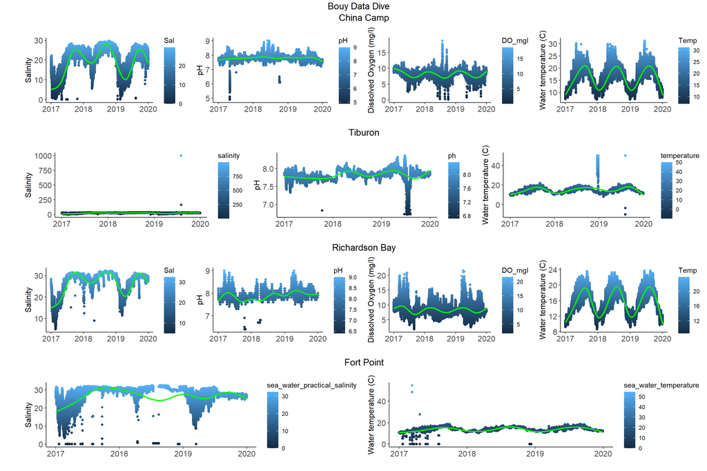

```r
allstack<-ggarrange(ccgraph, eosgraph,rbgraph,fpgraph,  ncol= 1, nrow = 4)

annotate_figure(allstack,
                top = text_grob("Bouy Data Dive", color = "black", face = "plain", size = 14), left = text_grob("", color = "black", rot = 90, size=12))
```